# Streaming Audience Analysis

by Leon Chan

## 1. What did you do to assess the data before starting the task?

Assess the data quality by checking:

- Duplicates in the audience id column (primary key - used to join datasets).
- Unique values in the categorical column for anomalies or mis-spelt categorical entries.
- Null values. There were only null values in the age and gender columns.
- Consistency of the data types across the different tables.

## 2. What did you find?

**Distribution of minutes streamed**

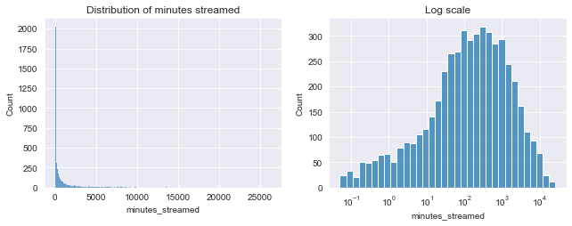

- Large dispersion ranging from 3 seconds to over 18 days (1.58 million seconds) worth of content streamed.
- Majority of the audience stream between 1 minute to 1,000 minutes. Peak count lies between the 10 minutes to 1000 minutes streamed range.
- 35% of the audience have streamed 1 hour of content or less.
- Additional information required: What time frame does this dataset cover?

**Distribution of age**

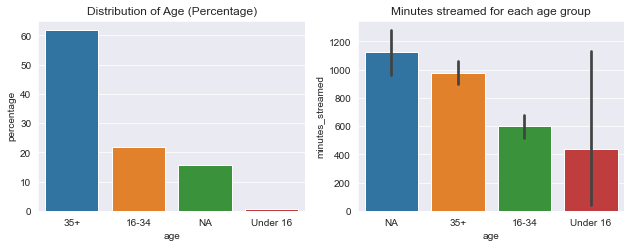

Distribution of age:

- Under 16 category is a small minority of the total percentage.
- Over 35+ makes up the majority with over 60%, this could be impacted by the wide age range it covers.

Minutes streamed for each age group:

- NA and 35+ age group streams the most number of minutes.
- Followed by 16-34 age group with a significant drop off.

**Distribution of gender**

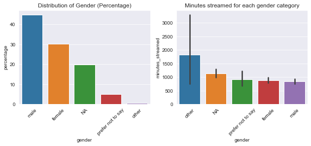

Distribution of gender:

- Large male audience (~45%) compared with female audience (~30%).
- Under 10% of the audience are in the 'other' or 'prefer not to say' category.

Minutes streamed for each gender category:

- Not enough data points for 'other' category resulting in a large error bar.
- NA category with one of the most minutes streamed.
- Minutes streamed for male and female are relatively even.

**Viewing habits between age groups and gender groups**

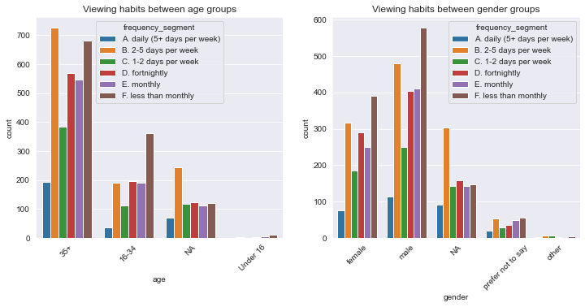

Viewing habits between age groups:

- One notable difference in viewing habits between the two most common age groups (35+ and 16-34) is the 2-5 days per week frequency segment.

Viewing habits between genders:

- Viewing habits relatively consistent between gender groups.

**Distinct networks and distinct programmes for each frequency segment**

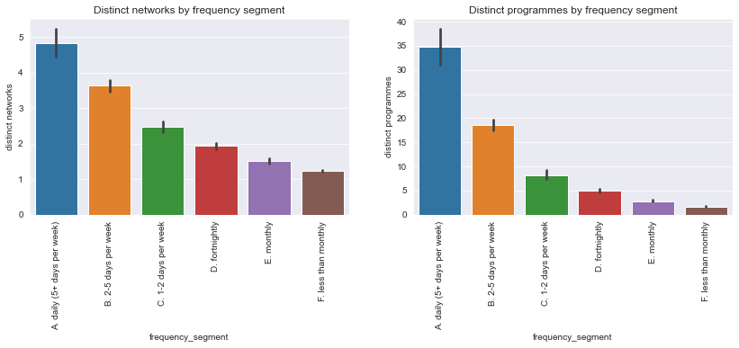

- The more frequent users are also more active. They tune into more distinct networks and programmes.
- 95% of the audience tunes into 7 distinct networks or less.
- 95% of the audience tunes into 36 programmes or less.

def ordinal_create(df, var_list):

```
"""Helper function to convert variables encoded as categoricals which are
actually ordinals. Uses a dictionary to remap, for example: 'F. less than monthly' to 1, 'E. monthly'
to 2, etc. Accepts a DataFrame and a list of variables to remap. Returns a
new DataFrame with edits applied.
Should be run after filling null values or columns with nulls come out as
float instead of int"""

qual_mapper = {'F. less than monthly': 1,
              'E. monthly': 2,
              'D. fortnightly': 3,
              'C. 1-2 days per week': 4,
              'B. 2-5 days per week': 5,
              'A. daily (5+ days per week)': 6}

for variable in var_list:
    update_df[variable] = update_df[variable].replace(qual_mapper)

return update_df
```

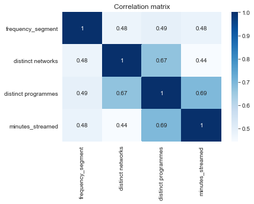

- Moderate to strong positive correlation between number of distinct networks and programmes used by the users.
- Moderate positive correlation between frequency segment and the number distinct networks, programmes and minutes streamed.

## 3. What other data would you need for further analysis?

- actual ages or number of days streamed per month for analysis using linear regression.
- dates and times to gain insight on listening activities and for trend analysis.
- geographic data of the audience.
- types of device used to stream our content.
- session data.
- programmes and network data: titles, categories and genres.